# Tutorial 3

Xia Jingyi

February 4, 2016

#### 1. Suppose your CEO wants you to derive KPIs for the following 2 variables:

1. waiting time
2. service satifaction

#### (a) Using the given dataset, derive for each KPI:

1. the appropriate statistical index
2. the appropriate statistical chart
- KPI for waiting time

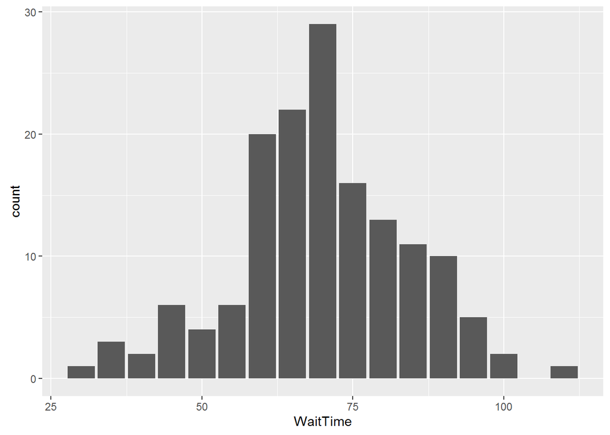

*Answer: From the histogram above, we can tell the median of waiting time is 70 minutes which can be used as a good statistical index.*

- KPI for service satisfaction

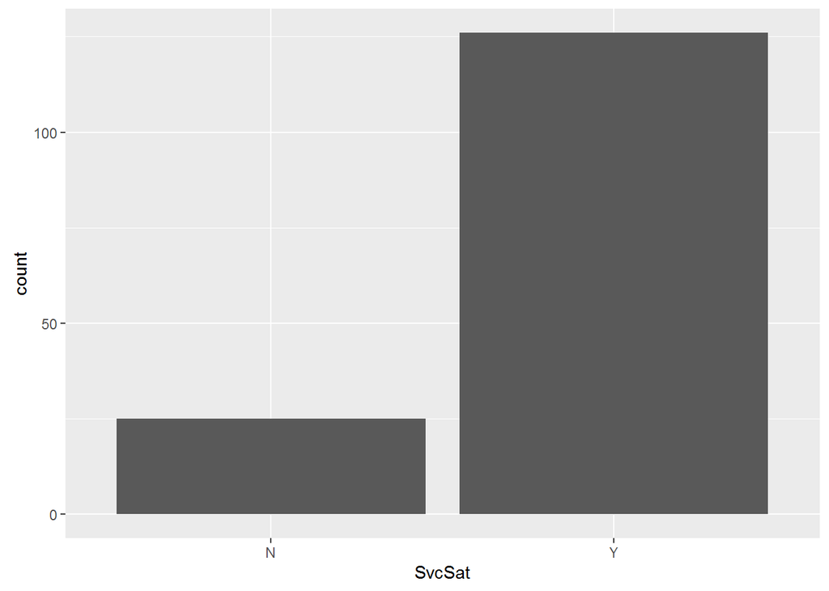

*Answer: From the histogram above, we can tell the median response of service satisfaction is Yes which can be used as a good statistical index.*

#### (b) Is there any statistical evidence to suggest differences in service satisfaction for age and gender? Comment on your findings.

- Customer satisfaction among **female** customers of different ages:

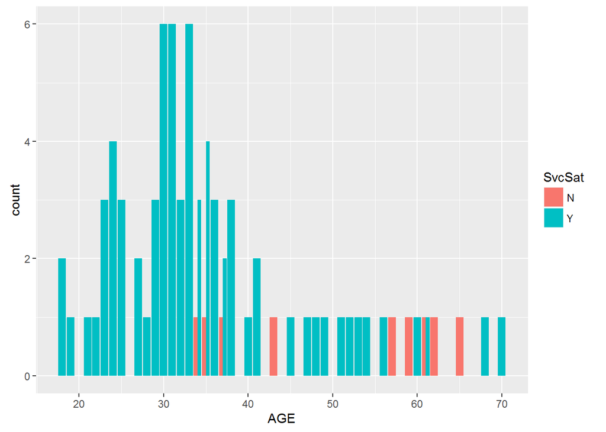

- Customer satisfaction among **male** customers of different ages:

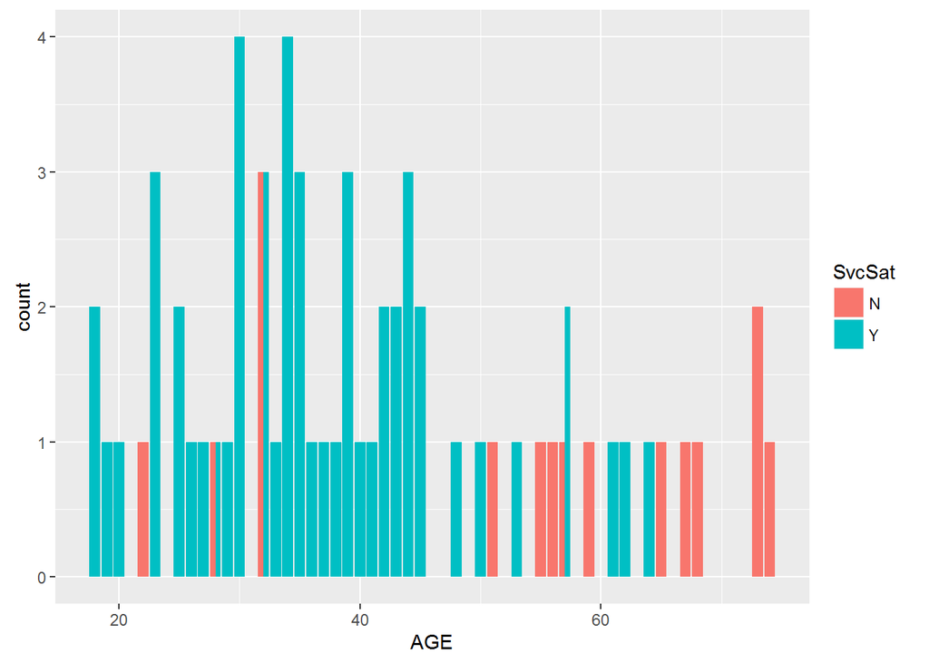

#### (c) Is there any statistical evidence to suggest that service satisfaction is correlated with waiting times?

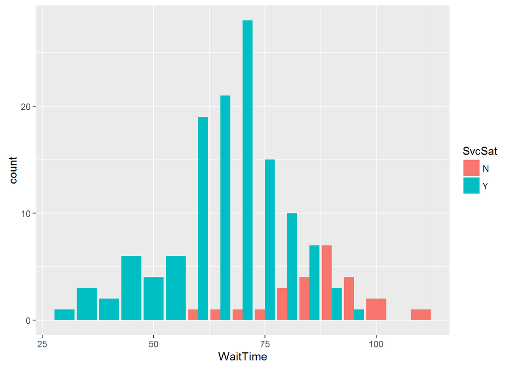

*Answer: From the histograms above, we can tell that the longer the waiting time, the more dissatisfication happens.*

#### (d) Compute the Body Mass Index for each patient and test whether the “BMIs” are correlated with “Total Cholesterol”

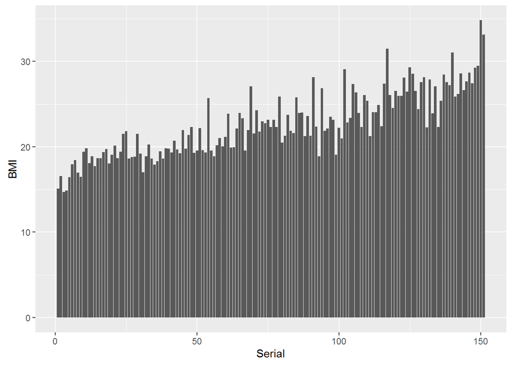

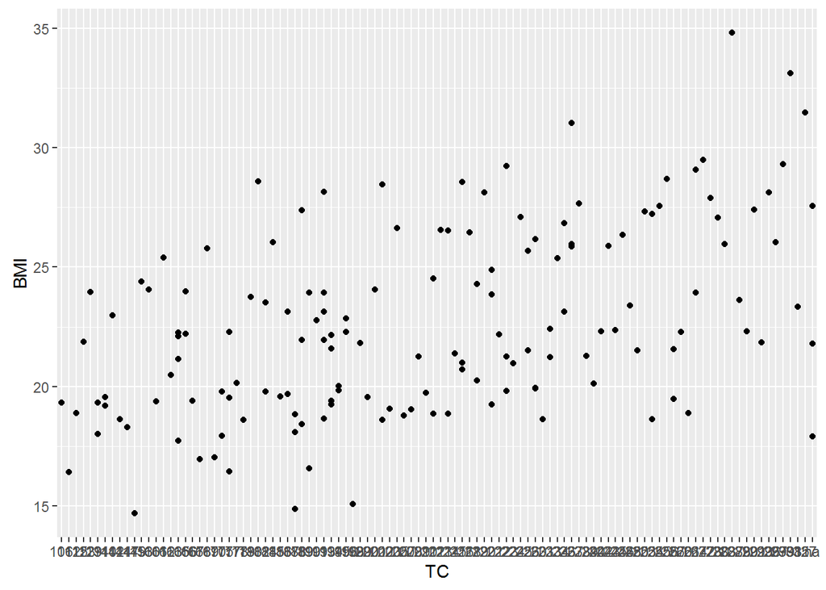

#### (e) Predict the “BMI” of a Chinese male patient whose age is 45 and SBP is 135 and TC is 150. What assumptions are necessary for the prediction to be valid?

```
##
## Call:
## lm(formula = c$bmi ~ var1 + var2 + c$AGE + c$SBP + c$TC)
##
## Coefficients:
## (Intercept)         var1         var2        c$AGE        c$SBP
##    10.12256     -0.89042      0.62397      0.01976      0.08618
##     c$TC112      c$TC115      c$TC123      c$TC129      c$TC131
##    -4.81516     -0.81701      2.98765      3.71970     -1.70116
##     c$TC140      c$TC142      c$TC144      c$TC147      c$TC149
##     0.73666      3.05286      0.34188      0.43957     -6.85032
##     c$TC153      c$TC160      c$TC161      c$TC162      c$TC163
##     1.85015      0.67713      1.23300      2.12541      1.16599
##     c$TC165      c$TC166      c$TC167      c$TC168      c$TC169
##    -0.38701      3.99932      0.66336     -0.49193      5.62090
##     c$TC170      c$TC175      c$TC177      c$TC178      c$TC179
##    -0.92818     -0.10238     -0.22174     -0.60029     -0.36517
##     c$TC180      c$TC182      c$TC184      c$TC185      c$TC186
##     4.39007      2.99240      1.48417      5.85425      0.15376
##     c$TC187      c$TC188      c$TC189      c$TC190      c$TC191
##     0.49182     -2.54038      0.50903      1.00722      4.27110
##     c$TC193      c$TC194      c$TC195      c$TC196      c$TC198
##     3.12262      0.19369     -0.01423      3.64493     -4.31736
##     c$TC199      c$TC200      c$TC201      c$TC202      c$TC203
##     1.46458     -0.20629      4.18923      4.27159     -1.18684
##     c$TC205      c$TC207      c$TC208      c$TC209      c$TC210
##     5.55911     -2.53717     -1.95839      1.05380      0.27302
##     c$TC212      c$TC213      c$TC214      c$TC215      c$TC216
##     2.22382      8.34155      2.87521      3.75384      2.45044
##     c$TC218      c$TC219      c$TC220      c$TC221      c$TC222
##     5.02661      3.08155      9.38949      3.10654      3.29313
##     c$TC223      c$TC224      c$TC225      c$TC226      c$TC230
##     2.92850     -0.52061      7.98536      2.54412      1.51649
##     c$TC231      c$TC233      c$TC234      c$TC236      c$TC237
##     0.89786      1.02633      4.50574      4.52278      6.65940
##     c$TC238      c$TC239      c$TC240      c$TC242      c$TC243
##     7.26511      0.90792      2.39685     -0.04005      6.96086
##     c$TC245      c$TC246      c$TC248      c$TC250      c$TC253
##     3.45982      7.01486      4.20651      2.64701      9.16578
##     c$TC254      c$TC255      c$TC256      c$TC257      c$TC260
##     2.37006      4.29871      7.47247     -0.21559     -3.32266
##     c$TC261      c$TC264      c$TC272      c$TC273      c$TC280
##    -0.41118      7.77706      7.91634      6.44308      7.35416
##     c$TC283      c$TC287      c$TC288      c$TC290      c$TC291
##     4.48779     14.15092      4.27525      0.98218      5.37823
##     c$TC293      c$TC296      c$TC297      c$TC299      c$TC308
##     1.27283      7.58057      2.92420      9.09008      6.71888
##     c$TC315      c$TC327       c$TCna
##     1.57123      8.76942      1.14858
```

```
##
## Call:
## lm(formula = c$bmi ~ var1 + var2 + c$AGE + c$SBP + c$TC)
##
## Residuals:
##     Min      1Q  Median      3Q     Max
## -4.6897 -0.0121  0.0000  0.0834  5.8426
##
## Coefficients:
##             Estimate Std. Error t value Pr(>|t|)
## (Intercept) 10.12256    4.20721   2.406  0.02050 *
## var1        -0.89042    1.04455  -0.852  0.39869
## var2         0.62397    0.96084   0.649  0.51953
## c$AGE        0.01976    0.04456   0.444  0.65960
## c$SBP        0.08618    0.03137   2.747  0.00874 **
## c$TC112     -4.81516    4.56515  -1.055  0.29742
## c$TC115     -0.81701    4.51706  -0.181  0.85732
## c$TC123      2.98765    4.43890   0.673  0.50451
## c$TC129      3.71970    4.33817   0.857  0.39596
## c$TC131     -1.70116    3.98540  -0.427  0.67162
## c$TC140      0.73666    3.90762   0.189  0.85136
## c$TC142      3.05286    4.52163   0.675  0.50318
## c$TC144      0.34188    4.44508   0.077  0.93905
## c$TC147      0.43957    4.55230   0.097  0.92352
## c$TC149     -6.85032    4.42828  -1.547  0.12920
## c$TC153      1.85015    4.58109   0.404  0.68831
## c$TC160      0.67713    4.52211   0.150  0.88167
## c$TC161      1.23300    4.45537   0.277  0.78330
## c$TC162      2.12541    4.83651   0.439  0.66254
## c$TC163      1.16599    4.55744   0.256  0.79929
## c$TC165     -0.38701    3.50973  -0.110  0.91271
## c$TC166      3.99932    3.90342   1.025  0.31130
## c$TC167      0.66336    4.62935   0.143  0.88673
## c$TC168     -0.49193    4.47744  -0.110  0.91303
## c$TC169      5.62090    4.32864   1.299  0.20102
## c$TC170     -0.92818    4.45530  -0.208  0.83595
## c$TC175     -0.10238    3.91887  -0.026  0.97928
## c$TC177     -0.22174    3.71329  -0.060  0.95266
## c$TC178     -0.60029    4.49825  -0.133  0.89446
## c$TC179     -0.36517    4.47378  -0.082  0.93532
```

[output cut: 69 more lines]

```
## c$TC291      5.37823    4.46814   1.204  0.23530
## c$TC293      1.27283    4.43211   0.287  0.77535
## c$TC296      7.58057    4.62996   1.637  0.10887
## c$TC297      2.92420    4.77198   0.613  0.54325
## c$TC299      9.09008    4.33453   2.097  0.04190 *
## c$TC308      6.71888    4.79094   1.402  0.16797
## c$TC315      1.57123    4.90139   0.321  0.75009
## c$TC327      8.76942    4.72408   1.856  0.07027 .
## c$TCna       1.14858    3.72646   0.308  0.75940
## ---
## Signif. codes:  0 '***' 0.001 '**' 0.01 '*' 0.05 '.' 0.1 ' ' 1
##
## Residual standard error: 3.052 on 43 degrees of freedom
## Multiple R-squared:  0.8224, Adjusted R-squared:  0.3806
## F-statistic: 1.861 on 107 and 43 DF,  p-value: 0.01153
```